# hw-01

Edit this “README.md” file and the “Rcode.rmd” file following the homework assignment instructions provided on our website.

# Biography

## Dilge Iris Girgin

### About me

Dilge Iris Girgin is a PhD student at the University of Chicago, specializing in International Relations and Sociology. She holds an MPhil in Politics and International Studies from the University of Cambridge and is currently a research associate at the Center for Foreign Policy and Peace Research (CFPPR). Outside of academia, Iris enjoys *playing squash, taking morning walks, and is an active advocate for animal welfare issues.*

Iris’s top 3 favorite songs are:

1. **Hey Jude** by The Beatles
2. **Mamma Mia** by ABBA
3. **Way Down We Go** by Kaleo

### A picture:

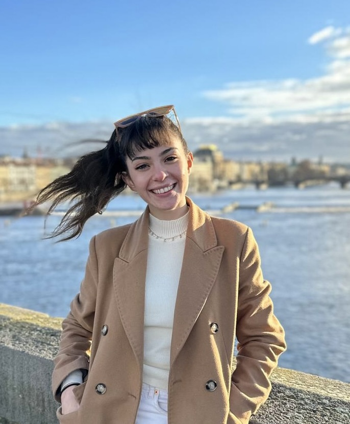

A picture of me

### A link to my linkedin page:

[A link to my LinkedIn page](https://www.linkedin.com/in/dilge-iris-girgin-599891224/en?original_referer=https%3A%2F%2Fwww.google.com%2F)

## Reflections

- Opened R Workbench
- Started a new project with File > New Project > Version Control > Git
- Created a new project
- Pulled changes from GitHub
- Made changes to the document following HW instructions
- Staged, committed, and pushed changes
- Verified from GitHub

## Evaluation of Homework

Linking my R and GitHub was difficult, but I learned how to add images to R, which was a new skill for me.

## Resources

- Emailed professor Nardin about why I couldn’t link R and GitHub and met with the TA for resolving the issue.